# Biostatistical Computing, PHC 6068

Dimension reduction

Zhiguang Huo (Caleb)

Monday September 25, 2017

# Outlines

Several popular dimension reduction approaches

- Principal component analysis (PCA)
- Singular value decomposition (SVD)
- Non-negative matrix factorization (NMF)
- Multi dimension scaling (MDS)

# Principal component analysis

- Can effectively perform dimension reduction
- A toy example of projecting 2-dimensional data onto 1-dimensional data.

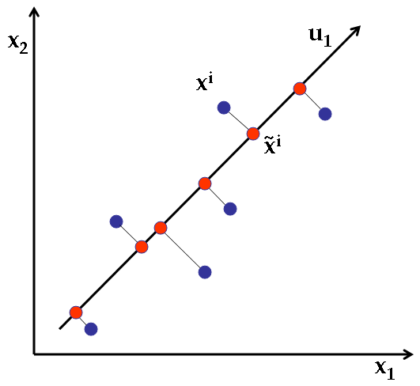

# Which direction to project?

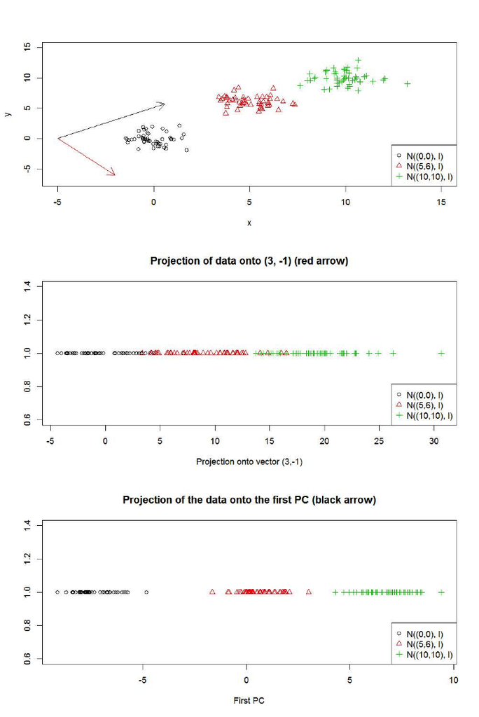

- The variance along the projected direction is maximized.

# Another motivating example

- Usually use first principle component and second principle component direction to visualize the data
- Motivating example: iris data, 150 observations, 4 variables (features)

```r
head(iris)
```

```
##   Sepal.Length Sepal.Width Petal.Length Petal.Width Species
## 1          5.1         3.5          1.4         0.2  setosa
## 2          4.9         3.0          1.4         0.2  setosa
## 3          4.7         3.2          1.3         0.2  setosa
## 4          4.6         3.1          1.5         0.2  setosa
## 5          5.0         3.6          1.4         0.2  setosa
## 6          5.4         3.9          1.7         0.4  setosa
```

```r
dim(iris)
```

```
## [1] 150   5
```

- Perform PCA
  - project these 4 features onto 2 dimensional space
- visualize the data.

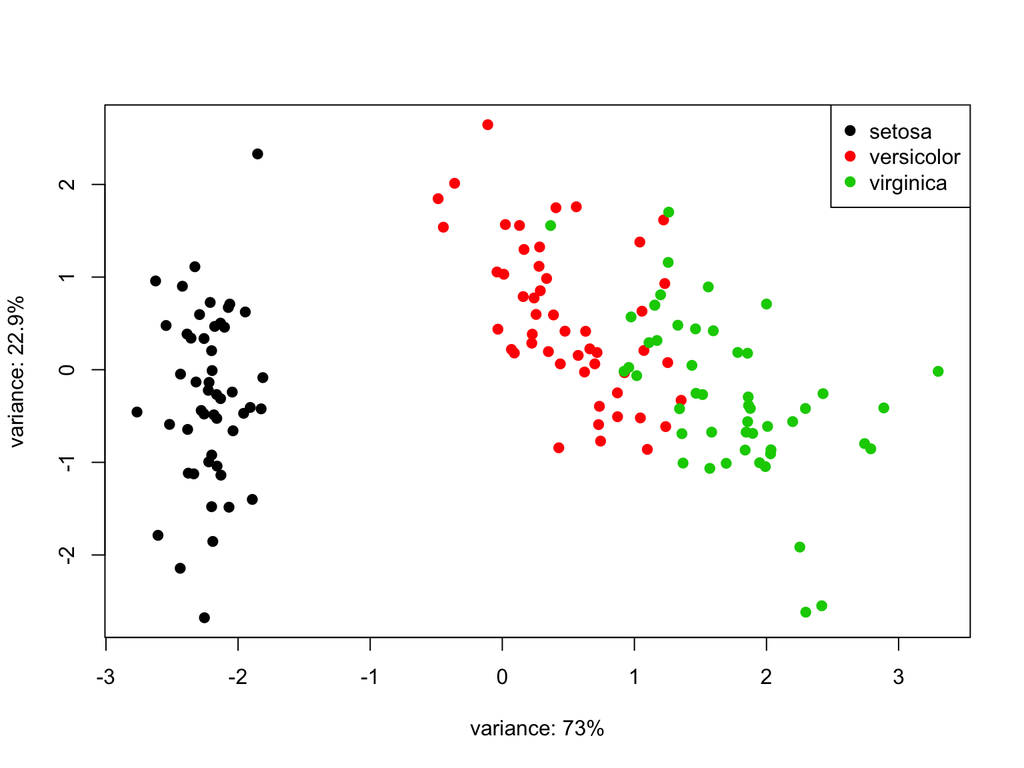

```r
iris.data <- iris[,1:4]
ir.pca <- prcomp(iris.data,
                 center = TRUE,
                 scale = TRUE)
PC1 <- ir.pca$x[,"PC1"]
PC2 <- ir.pca$x[,"PC2"]
variance <- ir.pca$sdev^2 / sum(ir.pca$sdev^2)
v1 <- paste0("variance: ",signif(variance[1] * 100,3), "%")
v2 <- paste0("variance: ",signif(variance[2] * 100,3), "%")
plot(PC1, PC2, col=as.numeric(iris$Species),pch=19, xlab=v1, ylab=v2)
legend("topright", legend = levels(iris$Species), col =  unique(iris$Species), pch = 19)
```

# Biplot

- Data points: Projection on first two PCs Distance in Biplot.
- Projection of sample onto arrow gives original (scaled) value of that variable.
- Arrowlength: Variance of variable.
- Angle between Arrows: Correlation.

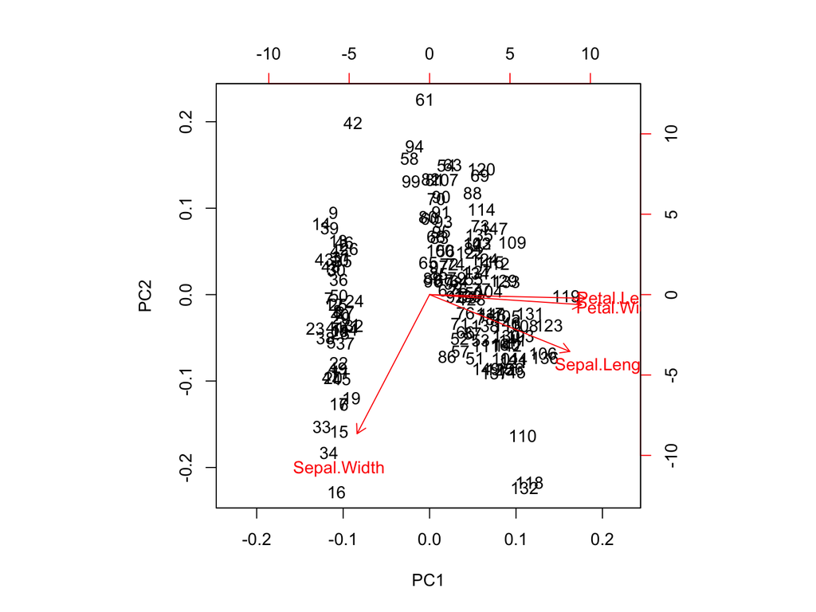

```r
biplot(ir.pca)
```

# Geometrical motivation for PCA (population version)

# Proof (page 1):

- Since $\Sigma \in \mathbb{R}^{G\times G}$ is a symmetric and positive - definite matrix, there exists matrix $V \in \mathbb{R}^{G\times G}$ and diagonal matrix $D \in \mathbb{R}^{G\times G}$ such that
  $$\Sigma = V D V^\top,$$

where $D = \begin{pmatrix} d_1 & 0 & 0 & \\ 0 & d_2 & & \\ 0 & & \ddots & 0\\ & & 0 & d_G \end{pmatrix},$

$d_1 \ge d_2 \ge \ldots \ge d_G \ge 0$ are eigenvalues. ${\bf V} = ({\bf v}_1, {\bf v}_2, \ldots, {\bf v}_G)$ are eigen-vectors.

- ${\bf V}$ are orthonormal
  - ${\bf v}_i^\top {\bf v}_j = 0$ if $i \ne j$
  - $\|{\bf v}_g\|^2 = {\bf v}_g^\top {\bf v}_g = 1$, $\forall 1 \le g \le G$
- $\Sigma {\bf v}_g = d_g {\bf v}_g$

# Proof (page 2):

For any vector $\alpha \in \mathbb{R}^{G}$, it can be spanned as linear combination of ${\bf v}_i$’s

- $\alpha = \sum_{g=1}^G a_g {\bf v}_g$.
  - $\sum_{g=1}^G a_g^2 = 1$ if $\|\alpha\|^2 = 1$
- When $\|\alpha\| = 1$,

$\begin{aligned} Var(\alpha^\top {\bf x}) &= \alpha^\top \Sigma \alpha \\ &= (\sum_{g=1}^G a_g {\bf v}_g)^\top \Sigma (\sum_{g=1}^G a_g {\bf v}_g) \\ &= (\sum_{g=1}^G a_g {\bf v}_g)^\top(\sum_{g=1}^G a_g d_g {\bf v}_g) \\ &= \sum_{g=1}^G d_g a_g^2 \|{\bf v}_g\|^2 = \sum_{g=1}^G d_g a_g^2 \\ &\le \sum_{g=1}^G d_1 a_g^2 \\ &\le d_1 \\ \end{aligned}$

# Proof (page 3):

- If $\alpha = {\bf v}_1$,

$\begin{aligned} Var(\alpha^\top {\bf x}) &= \alpha^\top \Sigma \alpha \\ &= {\bf v}_1^\top \Sigma {\bf v}_1 \\ &= d_1 \\ \end{aligned}$

- Therefore, $\alpha = {\bf v}_1$ maximize $\max_\alpha Var(\alpha^\top {\bf x})$.
- And the projected random variable $L_1 = {\bf v}_1^\top {\bf x}$ has the largest variance $d_1$

Similarly, $L_g = {\bf v}_g^\top {\bf x}$ has the largest variance among all possible projections orthogonal to $L_1, L_2, \ldots, L_{g-1}$ for $1 \le g \le G$.

# PCA 2D example

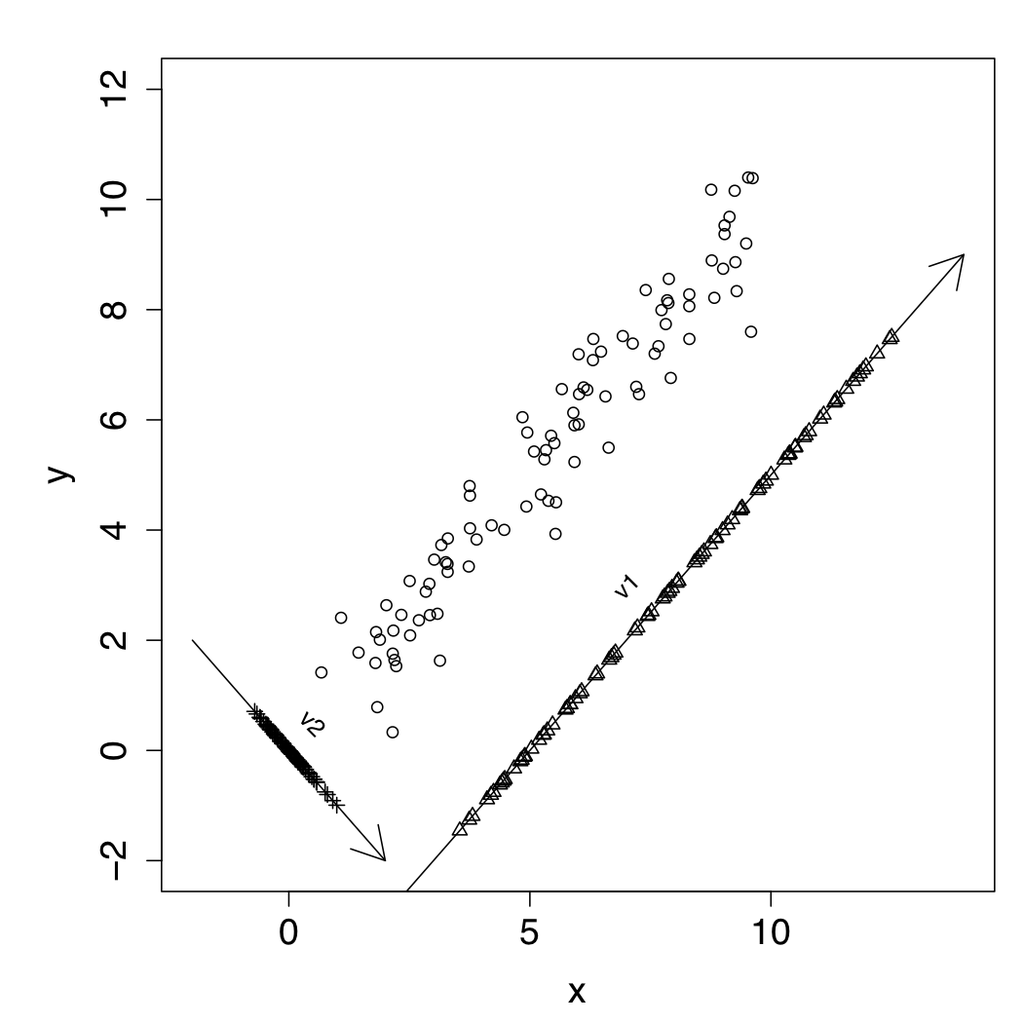

# Variance explained

- $trace(\Sigma)$ is sum of variance of all covariates, is invariant of change of basis.
- $trace(\Sigma) = \sum_{g} Var(L_g) = \sum_g d_g$.
- Define $r_g = \frac{d_g}{\sum_{g'} d_{g'}}$ where $r_g$ represents the proportion of variance explained by the $g^{th}$ PC.
- $R_g = \sum_{g'=1}^g r_{g'}$ is the cummulative proportion of variance explained by the first $g$ PCs.

# PCA summary

# Example 1, HAPMAP data

- The International HapMap Project was an organization that aimed to develop a haplotype map (HapMap) of the human genome, to describe the common patterns of human genetic variation.
- A subset of HAPMAP data:
  - CEU Utah residents with Northern and Western European ancestry from the CEPH collection
  - CHB Han Chinese in Beijing, China
  - JPT Japanese in Tokyo, Japan
  - YRI Yoruba in Ibadan, Nigeria
- 712,940 SNPs:
  - AA: 0
  - AB: 0.5
  - BB: 1

# HAPMAP data visualization

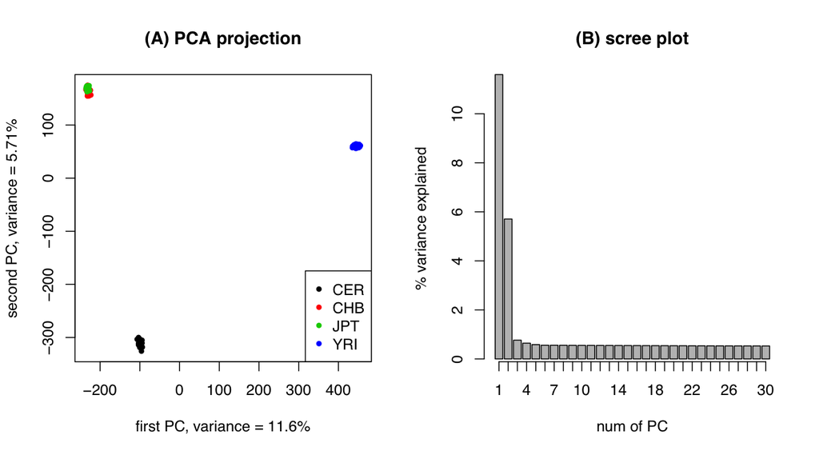

# In class exercise (Visualize HAPMAP data using chromosome 1)

- Human being have 23 chromosomes.
- Chromosome 1 of HAPMAP data is avaliable on /ufrc/phc6068/share/data/HAPMAP/chr1Data.Rdata
- Annotation is on /ufrc/phc6068/share/data/HAPMAP/relationships_w_pops_121708.txt
- These data are avaliable on hpg2.rc.ufl.edu
- You can either perform the analysis on HiperGator, or downloaded the data to your local computer and perform the PCA analysis.

# PCA steps (sample version)

- Center the data to mean 0 for each feature. (Sometimes also standardized the varaince to be 1).
- Calculate the sample covariance matrix.
- Perform eigen-value decomposition and obtain eigen-values and eigen-vectors.
- Project the original data onto the first eigen-vector,
  - the resulting projected value on the first eigen-vector is called first principal component.
  - the first eigen-value is the total variance explained by the first principal component.
- Repeat the projection step for the $k^{th}$ eigen-value and eigen-vectors, $(1 \le k \le K)$
  - the direction of $k^{th}$ eigen-vector is perpendicular to all previous eigen-vectors.
- Select $K$ using scree plot, or total variance is greater than certain threshold ($>90\%$)

# How many principal component to use?

- Scree plot

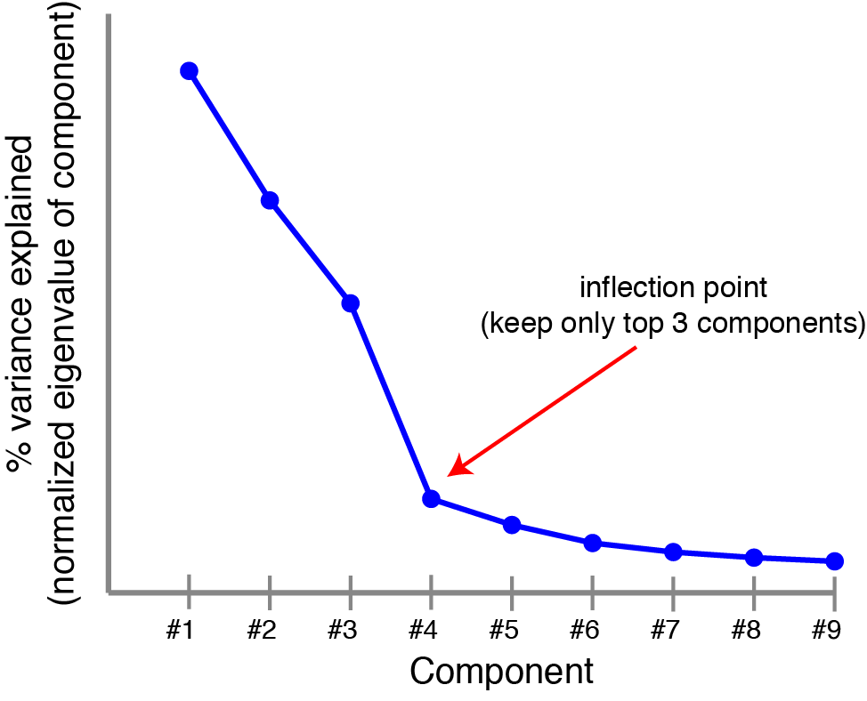

# Example 2, yeast cycle data

- The yeast cell cycle analysis project’s goal is to identify all genes whose mRNA levels are regulated by the cell cycle. http://genome-www.stanford.edu/cellcycle/
- contains the expression profile of 800 genes and their annotated cell cycle stage
  1. G1
  2. S
  3. S/G2
  4. G2/M
  5. M/G1
- Yeast cells were first synchronized to the same G0 stage by four different chemicals:
  - alpha
  - cdc15
  - cdc28
  - elu

# Example 2, yeast cycle data PCA for genes

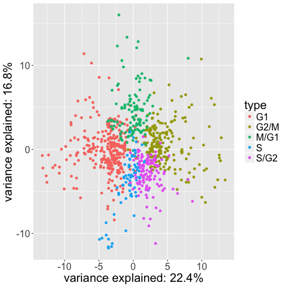

# Example 2, yeast cycle data PCA for samples

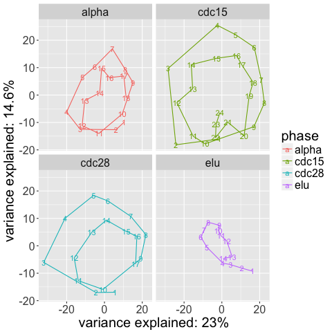

# Will be on HW

Repeat these two PCA plot

```r
library(impute)
raw = read.table(url("http://Caleb-Huo.github.io/teaching/data/cellCycle/cellCycle.txt"),header=TRUE,as.is=TRUE)
cellCycle = raw
cellCycle[,2:78]<- impute.knn(as.matrix(raw[,2:78]))$data ## missing value imputation
```

# Singular value decomposition (SVD)

- $X \in \mathbb{R}^{n \times p}$ is our data matrix with $n$ samples and $p$ features.
  - Without loss of generosity, $n < p$
- $X$ can be factorized as $U E_0 V_0^\top$
  - $U \in \mathbb{R}^{n \times n}$ such that $UU^\top = I_n$.
  - $E_0 \in \mathbb{R}^{n \times p}$. With $E_0 = (E, {\bf 0}_{n \times (p-n)})$, $E\in \mathbb{R}^{n \times n}$ is a diagnol matrix.
  - $V_0 \in \mathbb{R}^{p \times p}$. With $V_0 = (V, {\bf 0}_{p \times (p-n)})$, $V\in \mathbb{R}^{p \times n}$ such that $V^\top V= I_n$.
- Equivalently, $X = U E V^\top$
  - where $E = \begin{pmatrix} e_1 & 0 & 0 & \\ 0 & e_2 & & \\ 0 & & \ddots & 0\\ & & 0 & e_n \end{pmatrix},$

# Equivalence between PCA and SVD

$\begin{aligned} V^\top X^\top X V &= V^\top (U E V^\top)^\top U E V^\top V \\ &= V^\top V E U^\top U E V^\top V \\ &= E^2 \end{aligned}$

- Performing eigen-value decomposition on $X^\top X$ is equivalent to perform SVD on $X$
  - $V$ are eigen-vectors (projected directions)
  - $E^2$ are eigen-values (explained variances)
  - Projected value $XV = U E V^\top V = U E$

# Validate the SVD results using iris data

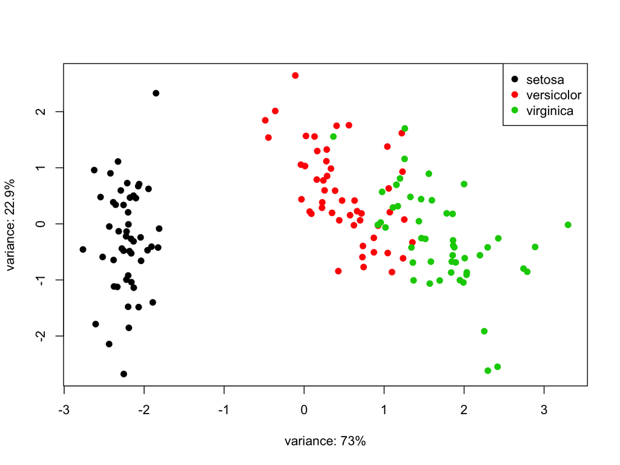

```r
iris.data <- iris[,1:4]
iris.data.center <- scale(iris.data)
asvd <- svd(iris.data.center)
UE <- asvd$u %*% diag(asvd$d)
PC1 <- UE[,1]
PC2 <- UE[,2]
variance <- asvd$d^2 / sum(asvd$d^2)
v1 <- paste0("variance: ",signif(variance[1] * 100,3), "%")
v2 <- paste0("variance: ",signif(variance[2] * 100,3), "%")
plot(PC1, PC2, col=as.numeric(iris$Species),pch=19, xlab=v1, ylab=v2)
legend("topright", legend = levels(iris$Species), col =  unique(iris$Species), pch = 19)
```

# Multi dimensional Scaling (MDS)

- Multi-dimensional scaling (MDS) aims to map data (distance or dissimilarity) structure to low dimensional space (usually 2D or 3D Euclidian space).
- Flight mileage of ten cities obtained from http://www.webyer.com/travel/mileage_calculator/.

```r
z <- read.delim(url("https://Caleb-Huo.github.io/teaching/data/UScityDistance/Mileage.txt"), row.names=1)
knitr::kable(z, caption = "distance between cities (miles)")
```

distance between cities (miles)

[output not shown]

# Multi dimensional Scaling (MDS)

- after apply MDS

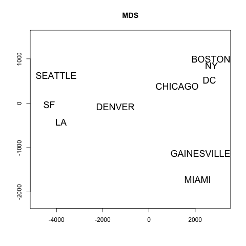

# Will be on HW

Perform MDS on the following data, with both classical method and Sammon’s stress.

# Math behind MDS

- objective function for classical MDS
  $$L = \min \sum_{i<j} (d_{ij} - \delta_{ij})^2$$
- parameters:
  - $i, j$: sample index
  - $\delta_{ij}$: the dissimilarity measure between object i and j in the original data space.
  - $d_{ij}$: the distance between the two objects after mapping to the targeted low-dimensional space.
- In the loss function above, large distances can dominate the optimization and ignore the local structure for pairs of short distances.
  - A possible modification may be to minimize the percent of squared loss.
    $$L = \min \sum_{i<j} (\frac{d_{ij} - \delta_{ij}}{\delta_{ij}})^2$$

# MDS with Sammon’s stress

- This modification, however, may over-emphasize the local structure and easily distort the global structure.
- A better balance between the two is the Sammon’s stress.
  $$L = \min (\frac{d_{ij} - \delta_{ij}}{\delta_{ij}})^2 \times w_{ij},$$
  $w_{ij} = \delta_{ij} / (\sum_{i<j} \delta_{ij})$

Note:

- Reflection, translation and/or rotation (i.e. isometry) of an MDS solution is also an MDS solution since MDS only considers the preservation of the dissimilarity structure.

# Classical mulditimensional scaling

- $\delta_{ij}$ is the observed distance between sample $i$ and $j$, ($1\le i \le n$, $1\le j \le n$).
- $D = \{d_{ij}\}_{1\le i,j \le n}$ is derived from Euclidean distance of an unnkown $n \times q$ data matrix $X \in \mathbb{n\times q}$ (Usually $q=2$).
  - $\|X_i - X_j\| = d_{ij}$.
  - Such a solution is not unique, because if $X$ is the solution, $X^* = X + c$, $c \in \mathbb{q}$ is also solution, since $\|X_i^* - X_j^*\| = \|(X_i + c) - (X_j + c)\| = \|X_i - X_j\|$
  - So suppose $X_i$ is centered, (i.e. $\sum_{i=1}^n X_{iq} = 0$, for all $q$).
  - $B = XX^\top$, $B_{ij} = b_{ij}$
- The following relationship can be derived
  - $d_{ij}^2 = b_{ii} + b_{jj} - 2b_{ij}$
  - $\sum_{i=1}^n b_{ij} = 0$
  - $T = trace(B) = \sum_{i=1}^n b_{ii}$
  - $\sum_{i=1}^n d_{ij}^2 = T + nb_{jj}$
  - $\sum_{j=1}^n d_{ij}^2 = T + nb_{ii}$
  - $\sum_{i=1}^n \sum_{j=1}^n d_{ij}^2 = 2 n T$

# Classical mulditimensional scaling continue

- We can solve for:
  $$b_{ij} = -1/2 (d_{ij}^2 - d{\cdot j}^2 - d{i\cdot}^2 + d_{\cdot\cdot}^2)$$
  - $d_{.j} = \frac{1}{n} \sum_{i = 1}^n d_{ij}$
  - $d_{i.} = \frac{1}{n} \sum_{j = 1}^n d_{ij}$
  - $d_{..} = \frac{1}{n^2} \sum_{i = 1}^n \sum_{j = 1}^n d_{ij}$
- Use $\delta_{ij}$ to approximate $d_{ij}$.
- A solution $X$ is then given by the eigen-decomposition of $B$.
  - $B = V\Lambda V^\top$
  - $X = \Lambda^{1/2} V^\top$

# MDS in R

- classical: cmdscale()
- MDS with Sammon’s stress: MASS::sammon()

# Another MDS example - Genetic dissimilarity between races

```r
z0 <- read.csv(url("https://Caleb-Huo.github.io/teaching/data/SNP_MDS/SNP_PCA.csv"), row.names=1)
knitr::kable(z0, caption = "Genetic dissimilarity between races")
```

Genetic dissimilarity between races

|  | X.Kung | Alur | AndhraBrahmin | CEU | CHB | Chinese | Dalit | Hema | Iban | Irula | JPT | Japanese | Khmer.Cambodian | Luhya | Madiga | Mala | Nguni | Pedi | Pygmy | Sotho.Tswana | Stalskoe | Tamil.Brahmin | Tuscan | Urkarah | Utah.N..European | Vietnamese |
| --- | --- | --- | --- | --- | --- | --- | --- | --- | --- | --- | --- | --- | --- | --- | --- | --- | --- | --- | --- | --- | --- | --- | --- | --- | --- | --- |
| !Kung | NA | NA | NA | NA | NA | NA | NA | NA | NA | NA | NA | NA | NA | NA | NA | NA | NA | NA | NA | NA | NA | NA | NA | NA | NA | NA |
| Alur | 0.050 | NA | NA | NA | NA | NA | NA | NA | NA | NA | NA | NA | NA | NA | NA | NA | NA | NA | NA | NA | NA | NA | NA | NA | NA | NA |
| Andhra_Brahmin | 0.168 | 0.135 | NA | NA | NA | NA | NA | NA | NA | NA | NA | NA | NA | NA | NA | NA | NA | NA | NA | NA | NA | NA | NA | NA | NA | NA |
| CEU | 0.183 | 0.154 | 0.033 | NA | NA | NA | NA | NA | NA | NA | NA | NA | NA | NA | NA | NA | NA | NA | NA | NA | NA | NA | NA | NA | NA | NA |
| CHB | 0.216 | 0.187 | 0.075 | 0.110 | NA | NA | NA | NA | NA | NA | NA | NA | NA | NA | NA | NA | NA | NA | NA | NA | NA | NA | NA | NA | NA | NA |
| Chinese | 0.213 | 0.179 | 0.071 | 0.108 | 0.001 | NA | NA | NA | NA | NA | NA | NA | NA | NA | NA | NA | NA | NA | NA | NA | NA | NA | NA | NA | NA | NA |
| Dalit | 0.178 | 0.143 | 0.010 | 0.056 | 0.078 | 0.075 | NA | NA | NA | NA | NA | NA | NA | NA | NA | NA | NA | NA | NA | NA | NA | NA | NA | NA | NA | NA |
| Hema | 0.052 | 0.013 | 0.108 | 0.123 | 0.162 | 0.153 | 0.116 | NA | NA | NA | NA | NA | NA | NA | NA | NA | NA | NA | NA | NA | NA | NA | NA | NA | NA | NA |
| Iban | 0.216 | 0.185 | 0.075 | 0.112 | 0.024 | 0.020 | 0.078 | 0.160 | NA | NA | NA | NA | NA | NA | NA | NA | NA | NA | NA | NA | NA | NA | NA | NA | NA | NA |
| Irula | 0.193 | 0.160 | 0.030 | 0.073 | 0.091 | 0.089 | 0.031 | 0.133 | 0.092 | NA | NA | NA | NA | NA | NA | NA | NA | NA | NA | NA | NA | NA | NA | NA | NA | NA |
| JPT | 0.218 | 0.188 | 0.076 | 0.112 | 0.007 | 0.009 | 0.079 | 0.163 | 0.030 | 0.092 | NA | NA | NA | NA | NA | NA | NA | NA | NA | NA | NA | NA | NA | NA | NA | NA |
| Japanese | 0.212 | 0.179 | 0.072 | 0.108 | 0.008 | 0.009 | 0.076 | 0.153 | 0.031 | 0.089 | 0.003 | NA | NA | NA | NA | NA | NA | NA | NA | NA | NA | NA | NA | NA | NA | NA |
| Khmer Cambodian | 0.199 | 0.162 | 0.055 | 0.094 | 0.012 | 0.009 | 0.059 | 0.136 | 0.013 | 0.075 | 0.018 | 0.018 | NA | NA | NA | NA | NA | NA | NA | NA | NA | NA | NA | NA | NA | NA |
| Luhya | 0.049 | 0.009 | 0.131 | 0.148 | 0.180 | 0.171 | 0.137 | 0.011 | 0.177 | 0.153 | 0.181 | 0.171 | 0.156 | NA | NA | NA | NA | NA | NA | NA | NA | NA | NA | NA | NA | NA |
| Madiga | 0.174 | 0.138 | 0.005 | 0.050 | 0.072 | 0.069 | 0.006 | 0.111 | 0.073 | 0.027 | 0.073 | 0.070 | 0.052 | 0.133 | NA | NA | NA | NA | NA | NA | NA | NA | NA | NA | NA | NA |
| Mala | 0.174 | 0.138 | 0.005 | 0.053 | 0.072 | 0.068 | 0.006 | 0.112 | 0.072 | 0.026 | 0.073 | 0.069 | 0.051 | 0.133 | 0.001 | NA | NA | NA | NA | NA | NA | NA | NA | NA | NA | NA |
| Nguni | 0.038 | 0.019 | 0.146 | 0.164 | 0.198 | 0.191 | 0.154 | 0.022 | 0.197 | 0.172 | 0.199 | 0.190 | 0.174 | 0.014 | 0.150 | 0.150 | NA | NA | NA | NA | NA | NA | NA | NA | NA | NA |
| Pedi | 0.036 | 0.016 | 0.140 | 0.157 | 0.192 | 0.184 | 0.147 | 0.018 | 0.190 | 0.165 | 0.193 | 0.184 | 0.167 | 0.010 | 0.143 | 0.143 | 0.004 | NA | NA | NA | NA | NA | NA | NA | NA | NA |
| Pygmy | 0.071 | 0.065 | 0.196 | 0.209 | 0.239 | 0.240 | 0.207 | 0.077 | 0.240 | 0.219 | 0.240 | 0.238 | 0.230 | 0.073 | 0.204 | 0.203 | 0.075 | 0.072 | NA | NA | NA | NA | NA | NA | NA | NA |
| Sotho/Tswana | 0.029 | 0.020 | 0.144 | 0.161 | 0.196 | 0.189 | 0.152 | 0.022 | 0.195 | 0.169 | 0.197 | 0.188 | 0.172 | 0.015 | 0.147 | 0.147 | 0.004 | 0.004 | 0.072 | NA | NA | NA | NA | NA | NA | NA |
| Stalskoe | 0.180 | 0.142 | 0.023 | 0.012 | 0.104 | 0.101 | 0.046 | 0.110 | 0.108 | 0.066 | 0.105 | 0.101 | 0.086 | 0.136 | 0.040 | 0.042 | 0.153 | 0.145 | 0.212 | 0.150 | NA | NA | NA | NA | NA | NA |
| Tamil_Brahmin | 0.170 | 0.135 | 0.001 | 0.033 | 0.078 | 0.074 | 0.010 | 0.107 | 0.080 | 0.032 | 0.080 | 0.075 | 0.058 | 0.130 | 0.006 | 0.006 | 0.146 | 0.139 | 0.199 | 0.143 | 0.023 | NA | NA | NA | NA | NA |
| Tuscan | 0.179 | 0.148 | 0.032 | 0.005 | 0.112 | 0.109 | 0.055 | 0.116 | 0.113 | 0.072 | 0.113 | 0.109 | 0.094 | 0.141 | 0.048 | 0.051 | 0.159 | 0.151 | 0.208 | 0.156 | 0.010 | 0.031 | NA | NA | NA | NA |
| Urkarah | 0.183 | 0.150 | 0.028 | 0.014 | 0.109 | 0.106 | 0.051 | 0.119 | 0.111 | 0.069 | 0.111 | 0.105 | 0.091 | 0.144 | 0.044 | 0.047 | 0.161 | 0.154 | 0.212 | 0.158 | 0.007 | 0.027 | 0.013 | NA | NA | NA |
| Utah N. European | 0.184 | 0.152 | 0.033 | 0.000 | 0.112 | 0.109 | 0.057 | 0.121 | 0.114 | 0.074 | 0.114 | 0.109 | 0.095 | 0.146 | 0.051 | 0.052 | 0.163 | 0.156 | 0.212 | 0.160 | 0.012 | 0.033 | 0.004 | 0.014 | NA | NA |
| Vietnamese | 0.210 | 0.175 | 0.066 | 0.104 | 0.006 | 0.002 | 0.071 | 0.148 | 0.014 | 0.086 | 0.014 | 0.015 | 0.003 | 0.167 | 0.064 | 0.064 | 0.186 | 0.180 | 0.238 | 0.185 | 0.099 | 0.070 | 0.105 | 0.102 | 0.105 | NA |
| YRI | 0.051 | 0.015 | 0.141 | 0.157 | 0.184 | 0.177 | 0.146 | 0.018 | 0.181 | 0.161 | 0.185 | 0.177 | 0.164 | 0.009 | 0.142 | 0.143 | 0.014 | 0.011 | 0.076 | 0.016 | 0.147 | 0.140 | 0.151 | 0.154 | 0.155 | 0.174 |

# Another MDS example - Genetic dissimilarity between races

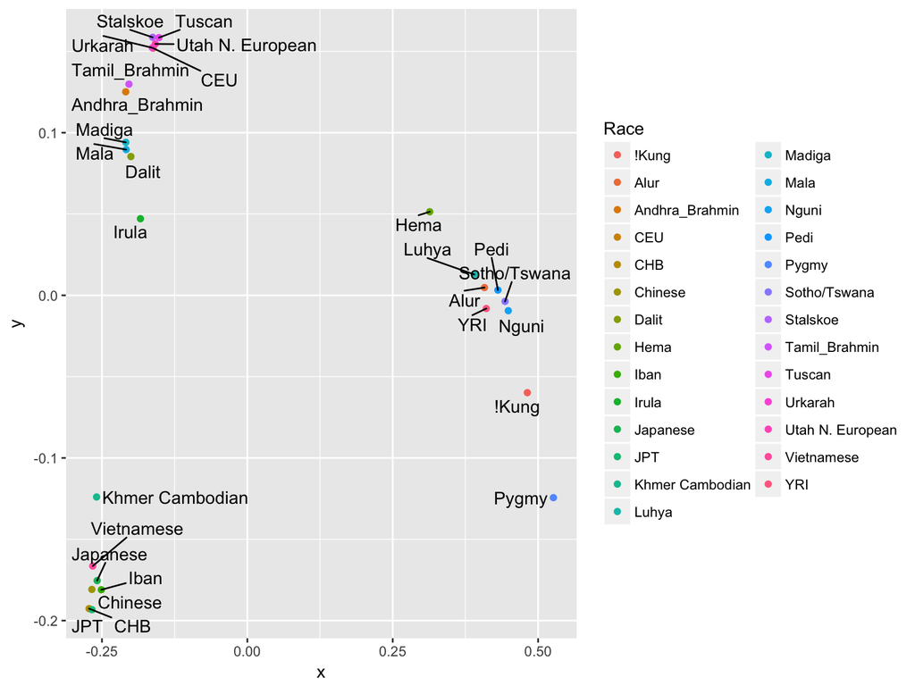

```r
library(ggplot2)
library(ggrepel)

z <- as.dist(cbind(z0,NA))
z_mds = - cmdscale(dist(z),k=2)

mdsDataFrame <- data.frame(Race=rownames(z_mds),x = z_mds[,1], y = z_mds[,2])

ggplot(data=mdsDataFrame, aes(x=x, y=y, label=Race)) + geom_point(aes(color=Race)) + geom_text_repel(data=mdsDataFrame, aes(label=Race))
```

# Non negetive matrix factorization (NMF)

- Non-negative matrix factorization (NMF) is a dimension reduction algorithm where a non-negative matrix, X, is factorized into two non-negative matrices
  - W and H, all elements must be equal to or greater than zero.
  - The method has been applied in image recognition, text mining and bioinformatics.

$$\min_{W\in \mathbb{R}^{p\times r}, H \in \mathbb{R}^{r \times n}} \|X - WH\|_F,$$
where $X \in \mathbb{R}^{p \times n}$, $\|X\|_F = \sqrt{\sum_{j=1}^p \sum_{i=1}^n X_{ji}^2}$

# NMF example

```r
library(NMF)
```

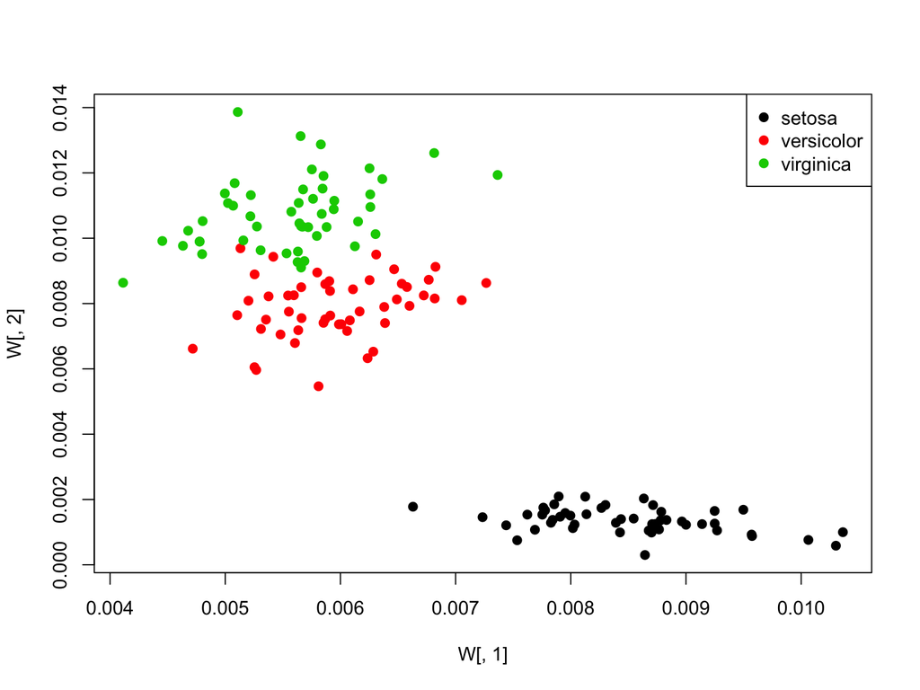

```r
iris.data <- iris[,1:4]
anmf <- nmf(iris.data, rank = 2, method = "lee")

W <- anmf@fit@W
H <- anmf@fit@H

plot(W[,1], W[,2], col=as.numeric(iris$Species),pch=19)
legend("topright", legend = levels(iris$Species), col =  unique(iris$Species), pch = 19)
```

# NMF example

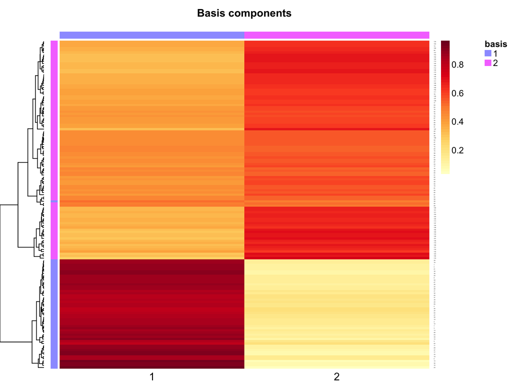

```r
basismap(anmf) ## W
```

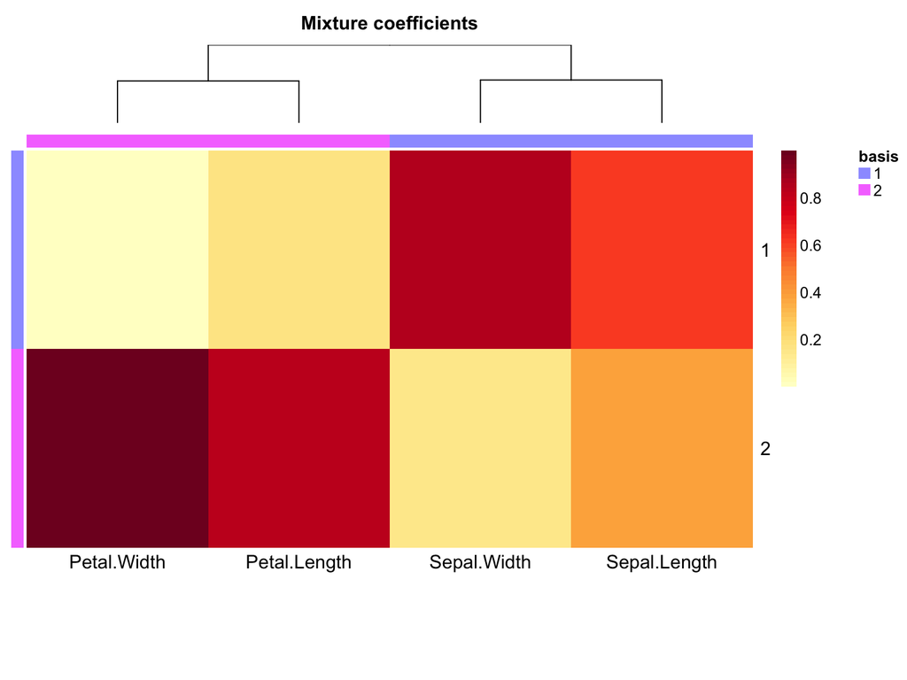

```r
coefmap(anmf) ## H
```

```r
knitr::purl("SVDandPCA.Rmd", output = "SVDandPCA.R ", documentation = 2)
```

```
##
##
## processing file: SVDandPCA.Rmd
```

[output not shown]

```
## output file: SVDandPCA.R
```

```
## [1] "SVDandPCA.R "
```